# What Actually Predicts a Hitter’s Next Season?

A Statcast-era OPS projection, built one regression at a time

Evan Heffelfinger

June 2026

## The question

Every offseason, fans and front offices guess what a hitter will do next year. The natural instinct is to look at what he just did. But last season’s line is a mix of *skill* and *luck*, and luck doesn’t carry over — which is why “he’ll repeat last year” is a famously bad bet.

This is a forecasting problem with a built-in trap. OPS is **defined** as on-base plus slugging, so using a season’s own OBP and SLG to “predict” its OPS is circular, it isn’t prediction at all. The honest version: predict a player’s OPS in a season using only what was knowable **before** it. That’s what this does, and it asks one extra question that the Statcast era makes possible: *do a hitter’s “expected” stats (what he should have produced based on how hard and at what angle he hit the ball) forecast next year better than what he actually produced?*

```r
pkgs <- c("Lahman", "dplyr", "tidyr", "tibble", "purrr", "readr", "httr",
          "ggplot2", "broom", "scales")
new <- pkgs[!pkgs %in% rownames(installed.packages())]
if (length(new)) install.packages(new)
invisible(lapply(c(pkgs, "baseballr"), library, character.only = TRUE))

set.seed(1)
dir.create("cache", showWarnings = FALSE)

TARGET_START   <- 2016   # Statcast-era target seasons
STATCAST_START <- 2015
TRAIN_END      <- 2022   # train on targets <= this; validate on later years
MIN_PA_TARGET  <- 250; MIN_PA_LAG1 <- 100
col_a <- "#2C7FB8"; col_b <- "#800000"; col_grey <- "#BDBDBD"
theme_set(theme_minimal(base_size = 12) +
          theme(panel.grid.minor = element_blank(),
                plot.title = element_text(face = "bold")))
```

## The data

Each row is one player-season we want to project (qualified hitters, 2016 onward). The features come **only** from earlier seasons: a Marcel-style blend of the prior three years’ OPS (recency- and playing-time-weighted, regressed toward league average and age-adjusted), prior-year plate discipline and batted-ball luck, age, home-park factor, and joined in from Baseball Savant via the Chadwick id crosswalk, the prior year’s **expected wOBA (xwOBA)**.

```r
bat_ps <- Batting |>
  filter(yearID >= 2012, yearID != 2020) |>
  group_by(playerID, yearID) |>
  summarise(across(c(AB, H, X2B, X3B, HR, BB, SO, HBP, SH, SF),
                   ~ sum(.x, na.rm = TRUE)), .groups = "drop") |>
  mutate(PA = AB + BB + HBP + SF, TB = H + X2B + 2*X3B + 3*HR,
         OBP = ifelse((AB+BB+HBP+SF) > 0, (H+BB+HBP)/(AB+BB+HBP+SF), NA_real_),
         SLG = ifelse(AB > 0, TB/AB, NA_real_), OPS = OBP + SLG,
         Kpct = ifelse(PA > 0, SO/PA, NA_real_),
         BABIP = ifelse((AB-SO-HR+SF) > 0, (H-HR)/(AB-SO-HR+SF), NA_real_))

league_year <- bat_ps |> group_by(yearID) |>
  summarise(H=sum(H), AB=sum(AB), BB=sum(BB), HBP=sum(HBP), SF=sum(SF),
            X2B=sum(X2B), X3B=sum(X3B), HR=sum(HR), .groups="drop") |>
  mutate(lg_ops = (H+BB+HBP)/(AB+BB+HBP+SF) + (H+X2B+2*X3B+3*HR)/AB) |>
  select(yearID, lg_ops)
lg_ops_overall <- mean(league_year$lg_ops)

people_df <- tryCatch(get("People"), error = function(e) get("Master"))
bio <- people_df |>
  transmute(playerID, bbrefID, birthYear, birthMonth, bats,
            nameFirst, nameLast)
debut_year <- Batting |> group_by(playerID) |>
  summarise(first_year = min(yearID), .groups = "drop")
park_year <- Batting |>
  filter(yearID >= 2012, yearID != 2020) |>
  group_by(playerID, yearID, teamID) |> summarise(AB=sum(AB), .groups="drop") |>
  group_by(playerID, yearID) |> slice_max(AB, n=1, with_ties=FALSE) |> ungroup() |>
  left_join(select(Teams, yearID, teamID, BPF), by=c("yearID","teamID")) |>
  transmute(playerID, yearID, park_bpf = as.numeric(BPF))

# Lagged + Marcel blend
lag1 <- bat_ps |> transmute(playerID, yearID = yearID + 1,
  lag1_OPS = OPS, lag1_SLG = SLG, lag1_Kpct = Kpct, lag1_BABIP = BABIP, lag1_PA = PA)
lag2 <- bat_ps |> transmute(playerID, yearID = yearID + 2, lag2_OPS = OPS, lag2_PA = PA)
lag3 <- bat_ps |> transmute(playerID, yearID = yearID + 3, lag3_OPS = OPS, lag3_PA = PA)

model_df <- bat_ps |> transmute(playerID, yearID, ops_target = OPS, pa_target = PA) |>
  left_join(lag1, by=c("playerID","yearID")) |>
  left_join(lag2, by=c("playerID","yearID")) |>
  left_join(lag3, by=c("playerID","yearID")) |>
  left_join(bio, by="playerID") |>
  left_join(debut_year, by="playerID") |>
  left_join(mutate(park_year, yearID = yearID + 1), by=c("playerID","yearID")) |>
  left_join(transmute(league_year, yearID = yearID + 1, lag1_lg_ops = lg_ops), by="yearID") |>
  mutate(age = yearID - birthYear - ifelse(!is.na(birthMonth) & birthMonth > 6, 1, 0),
         age_sq = age^2)

w1<-5; w2<-4; w3<-3; REG<-300
model_df <- model_df |>
  mutate(o1=coalesce(lag1_OPS,0), p1=coalesce(lag1_PA,0),
         o2=coalesce(lag2_OPS,0), p2=coalesce(lag2_PA,0),
         o3=coalesce(lag3_OPS,0), p3=coalesce(lag3_PA,0),
         num=w1*p1*o1+w2*p2*o2+w3*p3*o3, den=w1*p1+w2*p2+w3*p3,
         lgb=coalesce(lag1_lg_ops, lg_ops_overall),
         af = ifelse(age<29, 1+(29-age)*0.006, 1+(29-age)*0.003),
         marcel_ops = ((num + lgb*REG)/(den + REG))*af) |>
  select(-o1,-o2,-o3,-p1,-p2,-p3,-num,-den,-lgb,-af) |>
  filter(yearID >= TARGET_START, !is.na(lag1_OPS),
         lag1_PA >= MIN_PA_LAG1, pa_target >= MIN_PA_TARGET,
         !is.na(park_bpf), bats %in% c("L","R","B"),
         !is.na(age), !is.na(lag1_Kpct), !is.na(lag1_BABIP))
```

```r
# --- Pull prior-season xwOBA from Baseball Savant (cached after first run) ---
cache_get <- function(key, expr) {
  f <- file.path("cache", paste0(key, ".rds"))
  if (file.exists(f)) return(readRDS(f)); val <- force(expr); saveRDS(val, f); val
}
get_savant_csv <- function(url) {
  r <- httr::GET(url, httr::user_agent("Mozilla/5.0")); httr::stop_for_status(r)
  readr::read_csv(httr::content(r, as="text", encoding="UTF-8"), show_col_types = FALSE)
}
fetch_xwoba <- function(y) cache_get(sprintf("xstats_%d", y), {
  u <- sprintf(paste0("https://baseballsavant.mlb.com/leaderboard/expected_",
                      "statistics?type=batter&year=%d&min=50&csv=true"), y)
  ex <- get_savant_csv(u)
  tibble(key_mlbam = as.integer(ex$player_id), yearID = y,
         sc_xwoba = ex$est_woba, sc_xslg = ex$est_slg, sc_woba = ex$woba)
})

chad <- cache_get("chadwick", baseballr::chadwick_player_lu())
pid2mlbam <- bio |> filter(!is.na(bbrefID), bbrefID != "") |>
  distinct(playerID, bbrefID) |>
  inner_join(chad |> filter(!is.na(key_mlbam), !is.na(key_bbref), key_bbref != "") |>
               transmute(bbrefID = key_bbref, key_mlbam = as.integer(key_mlbam)),
             by = "bbrefID") |> distinct(playerID, key_mlbam)

statcast <- purrr::map_dfr(STATCAST_START:max(model_df$yearID), fetch_xwoba) |>
  inner_join(pid2mlbam, by = "key_mlbam")
sc_lag1 <- statcast |> transmute(playerID, yearID = yearID + 1,
  lag1_sc_xwoba = sc_xwoba, lag1_sc_xslg = sc_xslg, lag1_sc_woba = sc_woba)

dat <- model_df |>
  left_join(sc_lag1, by = c("playerID", "yearID")) |>
  filter(!is.na(lag1_sc_xwoba)) |>          # keep rows matched to Statcast
  mutate(bats = factor(bats))

cat(sprintf("Player-seasons used: %d  |  matched to Statcast: %.0f%%  |  years: %s\n",
            nrow(dat), 100 * nrow(dat) / nrow(model_df),
            paste(range(dat$yearID), collapse = "-")))
```

```
## Player-seasons used: 2194  |  matched to Statcast: 100%  |  years: 2016-2025
```

## The puzzle: which prior-season number sees the future best?

Before modeling, a simple question — of the things we could read off last year, which one *correlates* most with next year’s OPS? If `xwOBA` (a quality-of-contact measure that ignores whether the ball found a glove) keeps pace with raw OPS, that’s the tell that expected stats are worth carrying.

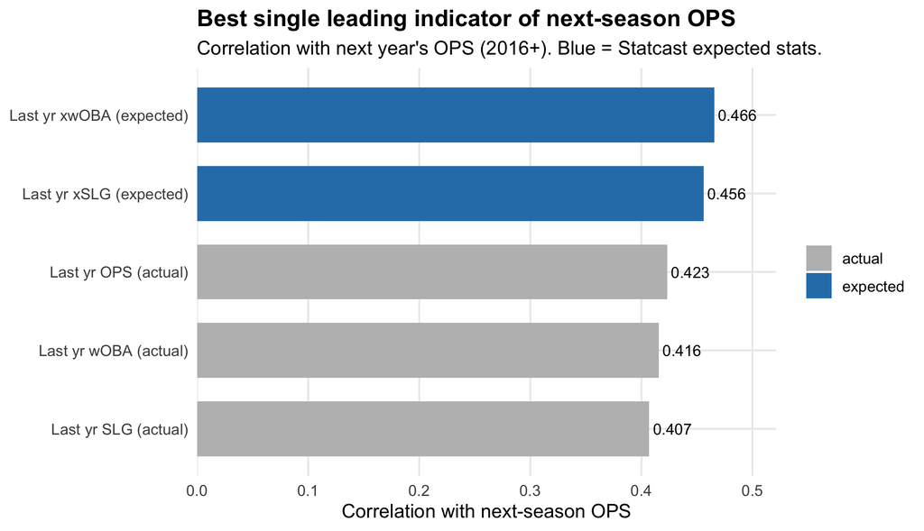

```r
cwt <- function(x) cor(x, dat$ops_target, use = "complete.obs")
cor_df <- tibble(
  metric = c("Last yr OPS (actual)", "Last yr SLG (actual)",
             "Last yr wOBA (actual)", "Last yr xwOBA (expected)",
             "Last yr xSLG (expected)"),
  r = c(cwt(dat$lag1_OPS), cwt(dat$lag1_SLG), cwt(dat$lag1_sc_woba),
        cwt(dat$lag1_sc_xwoba), cwt(dat$lag1_sc_xslg)),
  kind = c("actual","actual","actual","expected","expected"))

ggplot(cor_df, aes(r, reorder(metric, r), fill = kind)) +
  geom_col(width = 0.7) +
  geom_text(aes(label = sprintf("%.3f", r)), hjust = -0.1, size = 3.4) +
  scale_fill_manual(values = c(actual = col_grey, expected = col_a), name = NULL) +
  scale_x_continuous(expand = expansion(mult = c(0, 0.12))) +
  labs(title = "Best single leading indicator of next-season OPS",
       subtitle = "Correlation with next year's OPS (2016+). Blue = Statcast expected stats.",
       x = "Correlation with next-season OPS", y = NULL)
```

## Building the model, one layer at a time

A projection is really a stack of ideas. We add them as regression terms and watch the fit (adjusted R², which penalizes adding useless variables) climb.

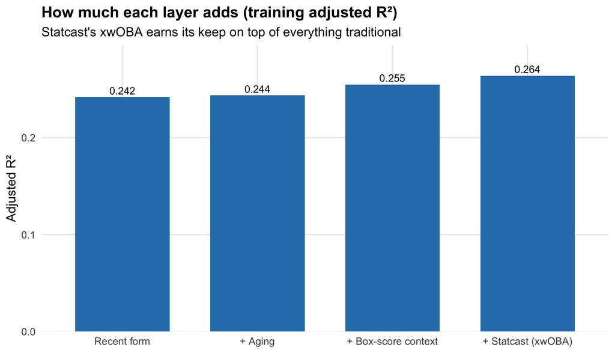

```r
train <- dat |> filter(yearID <= TRAIN_END)
test  <- dat |> filter(yearID >  TRAIN_END)

f1 <- ops_target ~ marcel_ops                                   # recent form
f2 <- ops_target ~ marcel_ops + age + age_sq                    # + aging
f3 <- ops_target ~ marcel_ops + age + age_sq +
        lag1_Kpct + lag1_BABIP + park_bpf + lag1_PA + bats       # + box-score context
f4 <- ops_target ~ marcel_ops + age + age_sq +
        lag1_Kpct + lag1_BABIP + park_bpf + lag1_PA + bats +
        lag1_sc_xwoba                                            # + Statcast

m1 <- lm(f1, train); m2 <- lm(f2, train)
m3 <- lm(f3, train); m4 <- lm(f4, train)

step_r2 <- tibble(
  step = factor(c("Recent form", "+ Aging", "+ Box-score context", "+ Statcast (xwOBA)"),
                levels = c("Recent form", "+ Aging", "+ Box-score context", "+ Statcast (xwOBA)")),
  adj_r2 = c(summary(m1)$adj.r.squared, summary(m2)$adj.r.squared,
             summary(m3)$adj.r.squared, summary(m4)$adj.r.squared))

ggplot(step_r2, aes(step, adj_r2)) +
  geom_col(fill = col_a, width = 0.7) +
  geom_text(aes(label = sprintf("%.3f", adj_r2)), vjust = -0.4, size = 3.4) +
  scale_y_continuous(expand = expansion(mult = c(0, 0.12))) +
  labs(title = "How much each layer adds (training adjusted R²)",
       subtitle = "Statcast's xwOBA earns its keep on top of everything traditional",
       x = NULL, y = "Adjusted R²")
```

The jump from the third bar to the fourth is the payoff: adding last year’s xwOBA lifts the fit even after the model already knows recent results, age, and discipline. Expected contact quality carries signal the box score misses.

## What the model says

Standardizing the inputs puts every coefficient on the same footing; each bar is the OPS change from a one-standard-deviation move in that predictor, holding the rest fixed.

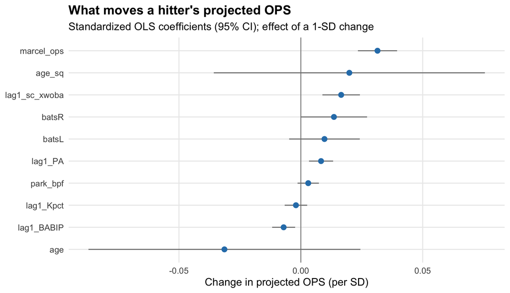

```r
num_p <- c("marcel_ops","age","age_sq","lag1_Kpct","lag1_BABIP","park_bpf",
           "lag1_PA","lag1_sc_xwoba")
train_std <- train |> mutate(across(all_of(num_p), ~ as.numeric(scale(.))))
m4_std <- lm(f4, train_std)

broom::tidy(m4_std) |>
  filter(term != "(Intercept)") |>
  mutate(lo = estimate - 1.96*std.error, hi = estimate + 1.96*std.error) |>
  ggplot(aes(estimate, reorder(term, estimate))) +
  geom_vline(xintercept = 0, colour = "grey60") +
  geom_segment(aes(x = lo, xend = hi, yend = reorder(term, estimate)), colour = "grey50") +
  geom_point(colour = col_a, size = 2.4) +
  labs(title = "What moves a hitter's projected OPS",
       subtitle = "Standardized OLS coefficients (95% CI); effect of a 1-SD change",
       x = "Change in projected OPS (per SD)", y = NULL)
```

## The aging curve, recovered

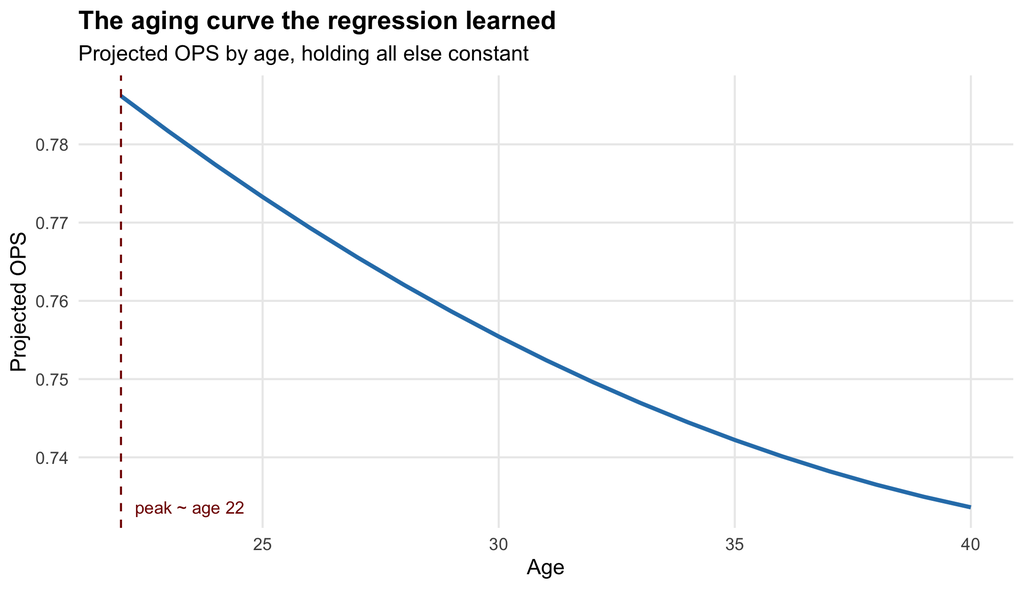

```r
agrid <- 22:40
nd <- tibble(age = agrid, age_sq = agrid^2,
             marcel_ops = mean(train$marcel_ops),
             lag1_Kpct = mean(train$lag1_Kpct), lag1_BABIP = mean(train$lag1_BABIP),
             park_bpf = mean(train$park_bpf), lag1_PA = mean(train$lag1_PA),
             lag1_sc_xwoba = mean(train$lag1_sc_xwoba),
             bats = factor("R", levels = levels(train$bats)))
nd$proj <- predict(m4, newdata = nd)
peak <- nd$age[which.max(nd$proj)]

ggplot(nd, aes(age, proj)) +
  geom_line(colour = col_a, linewidth = 1.1) +
  geom_vline(xintercept = peak, linetype = "dashed", colour = col_b) +
  annotate("text", x = peak + 0.3, y = min(nd$proj), hjust = 0, colour = col_b,
           size = 3.4, label = sprintf("peak ~ age %d", peak)) +
  labs(title = "The aging curve the regression learned",
       subtitle = "Projected OPS by age, holding all else constant",
       x = "Age", y = "Projected OPS")
```

## Does it actually work?

Numbers explained in-sample mean little; the test is unseen seasons. Trained through 2022 and checked on 2023–2025, the regression is compared to two honest baselines.

```r
rmse <- function(a, p) sqrt(mean((a - p)^2))
r2   <- function(a, p) 1 - sum((a - p)^2) / sum((a - mean(a))^2)
yte  <- test$ops_target
pred_reg <- predict(m4, newdata = test)

scores <- tibble(
  Approach = c("Persistence (last yr OPS)", "Marcel blend", "Regression + Statcast"),
  RMSE = c(rmse(yte, test$lag1_OPS), rmse(yte, test$marcel_ops), rmse(yte, pred_reg)),
  R2   = c(r2(yte, test$lag1_OPS),  r2(yte, test$marcel_ops),  r2(yte, pred_reg)))
scores
```

| Approach | RMSE | R2 |
| --- | --- | --- |
| Persistence (last yr OPS) | 0.10017156 | -0.1849164 |
| Marcel blend | 0.08669099 | 0.1125442 |
| Regression + Statcast | 0.08008019 | 0.2427330 |

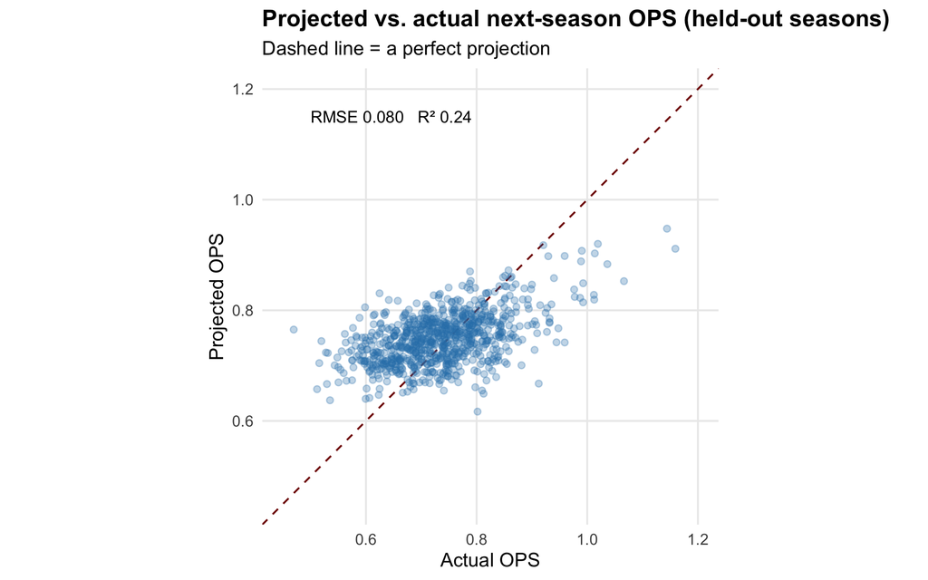

```r
ggplot(tibble(actual = yte, pred = pred_reg), aes(actual, pred)) +
  geom_abline(slope = 1, intercept = 0, colour = col_b, linetype = "dashed") +
  geom_point(alpha = 0.3, colour = col_a) +
  annotate("text", x = 0.5, y = 1.15, hjust = 0, size = 3.6,
           label = sprintf("RMSE %.3f   R² %.2f",
                           rmse(yte, pred_reg), r2(yte, pred_reg))) +
  coord_equal(xlim = c(0.45, 1.2), ylim = c(0.45, 1.2)) +
  labs(title = "Projected vs. actual next-season OPS (held-out seasons)",
       subtitle = "Dashed line = a perfect projection",
       x = "Actual OPS", y = "Projected OPS")
```

*Data: Lahman database (traditional stats, bio, park factors) and Baseball Savant (expected stats), linked via the Chadwick register. Code folded throughout — click “Code” to expand any section.*